# Metodologia badań medycznych. Streszczenie.

Agata Zywert

3 czerwca 2018

### Etyka a badania medyczne

##### Normy etyczne mogą opierać się na następujących systemach wartości:

- moralność (nierzadko mylona właśnie z etyką),
- religia,
- kultura, obyczaje,
- prawo,
- ugruntowane zasady wykonywania danego zawodu (etyka zawodowa – np. lekarska).

##### Konflikt interesu w badaniach medycznych:

- **interes jednostki** – pacjenta (chęć poprawy stanu zdrowia) albo zdrowego ochotnika uczestniczącego w badaniu (interes zarobkowy),
- **interes badacza** – lekarza oraz jego zespołu badawczego: może to być interes naukowy (zwłaszcza w przypadku badań niekomercyjnych), interes zarobkowy (zwłaszcza w przypadku badań komercyjnych), prestiż uczestnictwa w renomowanym projekcie badawczym; wiele badań medycznych jest projektami naukowymi najwyższej próby, dążącymi do poznania nieznanych jeszcze mechanizmów działania leków czy funkcjonowania organizmu ludzkiego, np. mechanizmów immunologicznych,
- **interes społeczeństwa** (chęć uzyskania dostępu do lepszych, to jest bardziej skutecznych i bezpiecznych metod leczenia),
- **interes przedsiębiorcy** (np. ﬁrmy farmaceutycznej sponsorującej badanie) – w przypadku badań komercyjnych (badanie kliniczne jako inwestycja w nowy lek, która w przyszłości przyniesie zyski).

`Tu Pablo wymienia różne kodeksy o etyce wymienię je też, ale już nie będę cytować`

- Przysięga Hipokratesa
- Przyrzeczenie lekarskie
- Kodeks norymberski
- Deklaracja Helsińska

`Potem jest historia o Talidomidzie` > Talidomid był sprzedawany bez recepty w latach 1957–1961 jako lek usypiający ogólnego stosowania, a w większych dawkach jako lek przeciwbólowy dla kobiet, których ciąża przebiegała z powikłaniami. A potem się okazało, że źle działa na płód. A na koniec się okazało, ze zmniejsza szansę odrzucenia przeszczepu. Nie wiem po co to całe info.

### Badania medyczne

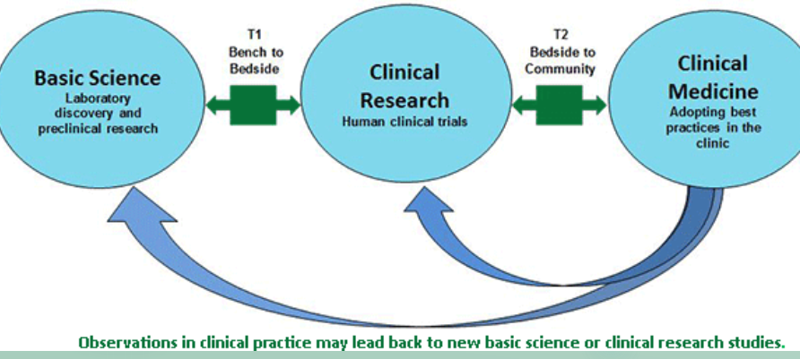

[figure not shown]

### Medycyna translacyjna

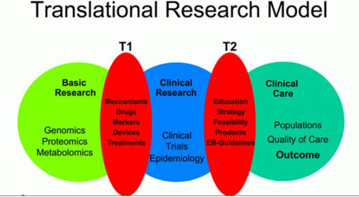

`następuję gadanie o następujących rzeczach`

#### Niezbyt istotne info:

- **Gdzie pozyskać hajs na badania** - Narodowe Centrum Badań i Rozwoju, Fundacja na Rzecz Nauki Polskiej
- **Co to jest impact factor** - to chyba wiecie :P
- **Jak wybrać pismo**
- **Twoje badanie potrzebuje recenzji**

#### Jak czytać teksty naukowe?

##### **Wagę tekstu naukowego należy oceniać w zależności od tego, jaką przyjmiemy perspektywę w takiej ocenie:**

- zdolność do udowodnienia postulowanej hipotezy
- wkład w odkrywanie nowych mechanizmów, zjawisk i etiologii

##### **Hierarchia schematów badawczych ze względu na możliwość udowadniania:**

1. Randomizowane badania kliniczne
2. Prospektywne badania kohortowe
3. Retrospektywne badania kohortowe
4. Badania kliniczno-kontrolne (case-control)
5. Opisy przypadków, badania ekologiczne i przekrojoweDotyczy sytuacji, w której prawdopodobieństwo a priori weryﬁkowanej hipotezy jest duże (50:50).

##### **Hierarchia schematów badawczych ze względu na możliwość odkrywania nowych zjawisk:**

1. Opisy przypadków, przegląd danych literaturowych
2. Badania kliniczno-kontrolne (case-control)Retrospektywne badania kohortoweProspektywne badania kohortowe
3. Randomizowane badania kliniczne Dotyczy sytuacji, w której prawdopodobieństwo a priori weryﬁkowanej hipotezy jest bardzo małe (1:100-1:100 000)

##### **Na jakie pytanie autorzy artykułu starają się odpowiedzieć?**

#### Cel badania powinien zostać opisany z uwzględnieniem wskazanych powyżej elementów:

- u jakich pacjentów, za pomocą jakiej interwencji, co chce się wykazać i w porównaniu do czego?
- w jakim schemacie badawczym autorzy dokonują analizy problemu badawczego?

#### Dlaczego stosuje się randomizację?

- Aby zapewnić równy rozkład czynników ryzyka dla leczonej choroby w grupie interwencji i grupie kontrolnej.
- Dzięki randomizacji zapewniamy zrównoważony rozkład również wszystkich innych czynników zakłócających, o których niekoniecznie musimy wiedzieć, że są czynnikami ryzyka choroby.
- To czy randomizacja była skuteczna, można stwierdzić porównując charakterystyki pacjentów na początku badania.

#### Na drugim miejscu oceny wiarygodności jest zbadanie zgodności kryteriów włączenia z proﬁlem klinicznym pacjentów faktyczniewłączonych do badania.

#### Zgodność ta skutkuje poprawnością wnioskowania o skuteczności leczenia w populacji pacjentów, którą opisano jako uczestniczącą w badaniu (internal validity).

- Czy wyniki są wiarygodne?
- Czy dobór chorych do grup był przeprowadzony losowo?
- Czy właściwie przeanalizowano dane wszystkich chorych zakwaliﬁkowanych do badania oraz czy zostali oni odpowiednio przydzieleni do grup w momencie jego zakończenia?Czy zakończono obserwację odległą?
- Czy analizy końcowe dokonywano w tych grupach, do których pacjenci byli zakwaliﬁkowani losowo na początku?
- Czy nie zmieniono grup pacjentów?
- Czy pacjenci, personel medyczny i członkowie zespołu badawczego pozostawali nieświadomi istoty metody terapeutycznej?
- Czy w momencie rozpoczęcia badania grupy były porównywalne?
- Czy poza terapią eksperymentalną pacjenci w obu grupach traktowani byli jednakowo?

#### **Zasada intention-to treat (ITT) analysis – analiza zgodnie z zamiarem leczenia.**

- Zakłada ona przeprowadzenie analizy pacjentów i ich danych o zdarzeniach klinicznych w przebiegu badania w tej grupie, do której zostali losowo przydzieleni bez względu na to czy pacjent w grupie aktywnego leczenia przestał przyjmować lek (np. z powodu działań niepożądanych) lub w grupie placebo zaczął przyjmować lek (bo np. pojawiły się wskazania do leczenia).
- Przestrzeganie tej zasady pozwala ocenić praktyczną skuteczność leczenia. Teoretyczna skuteczność ma znacznie mniejsze znaczenie dla praktyki klinicznej i oceniana jest w tzw. analizie as treated, tzn. w grupach pacjentów, którzy faktycznie otrzymywali leczenie, niedoświadczając z tego powodu żadnych niedogodności, które spowodowałyby jego przerwanie.

#### Miarą siły efektu terapeutycznego lub szkodliwości jest wartość **ryzyka względnego (Relative Risk – RR)**, **wskaźnika hazardu (Hazard Ratio)** w badaniach oceniających czas do zdarzenia **(analiza przeżycia)** lub

**ilorazu szans (Odds Ratio)** w badaniach kliniczno-kontrolnych. Im większe zmniejszenie lub zwiększenie, tym silniejszy efekt.

#### Artykuły dotyczące diagnostyki powinny zawierać w sobie odpowiedzi na poniższe pytania:

- Czy wyniki proponowanego testu diagnostycznego porównano z niezależnie wykonanym i interpretowanym testem referencyjnym?
- Czy pacjenci uwzględnieni w analizie w pełni reprezentowali populację z badanym stanem zdrowia?
- Czy sposób przeprowadzania testu i metody interpretacji opisano w sposób umożliwiający ich odtworzenie?
- Jaka jest czułość i swoistość testu? Czy dzięki zastosowaniu testu poprawię rokowanie pacjentów?

#### Obserwacja naukowa

- **Zbiór obiektów będących przedmiotem obserwacji** (np. pacjenci, zwierzęta laboratoryjne, wybrane procesy fizjologiczne lub patologiczne)
- **Zbiór cech obiektów** (np. wartość ciśnienia tętniczego, temperatury)
- **Metoda pomiaru** (np. czujnik pomiaru ciśnienia tętniczego, termometr)
- **Zbiór warunków w jakich jest wykonywana obserwacja** (np. warunki komfortu cieplnego)

##### Obserwowalność cechy obiektu:

1. Obserwowalna
2. Nieobserwowalna
3. Nieobserwowalność względna
4. Nieobserwowalność bezwzględna

##### **Powtarzalność obserwacji**

Zmienność: 1. Wewnątrz-osobnicza 2. Zewnątrz-osobnicza

##### **Układ obserwacji**

Obserwacje: 1. Powiązane 2. Niepowiązane

#### **Zbiór cech obiektów**

Ilość rejestrowanych parametrów: 1. Jeden 2. Więcej niż jeden

##### **Skale pomiarowe**

1. Ciągła
2. Dyskretna
   - Nominalna
   - Porządkowa
   - Przedziałowa (Interwałowa)
   - Ilorazowa

##### **Obraz kliniczny chorego:**

- **Badanie podmiotowe** (rozmowa z chorym)
- **Badanie przedmiotowe** (fizykalne)
- **Badania dodatkowe** (w tym laboratoryjne)

> Szacuje się, że ok. 70% decyzji klinicznych podejmowanych jest na podstawie badań dodatkowych.

##### **Interpretacja wyniku badania laboratoryjnego**

- Relacja uzyskanego wyniku do wybranego punktu odniesienia
  - Czy wynik jest dodatni (sygnalizuje obecność choroby)?
  - Czy wynik jest ujemny (nie wskazuje na obecnośc choroby)?
- Charakterystyka diagnostyczna przeprowadzonego badania
  - Wiedza o praktycznej przydatności wyniku w różnych sytuacjach klinicznych (np. czułość i swoistość diagnostyczna)
- Charakterystyka epidemiologiczna pacjenta
  - Jakie jest prawdopodobieństwo istnienia określonej choroby (jeszcze przed wykonaniem badania)?

`potem następuję info o granicach decyzyjnych, punktu odcięcia itp. - to było na Tomku więc tylko wstawie obrazki`

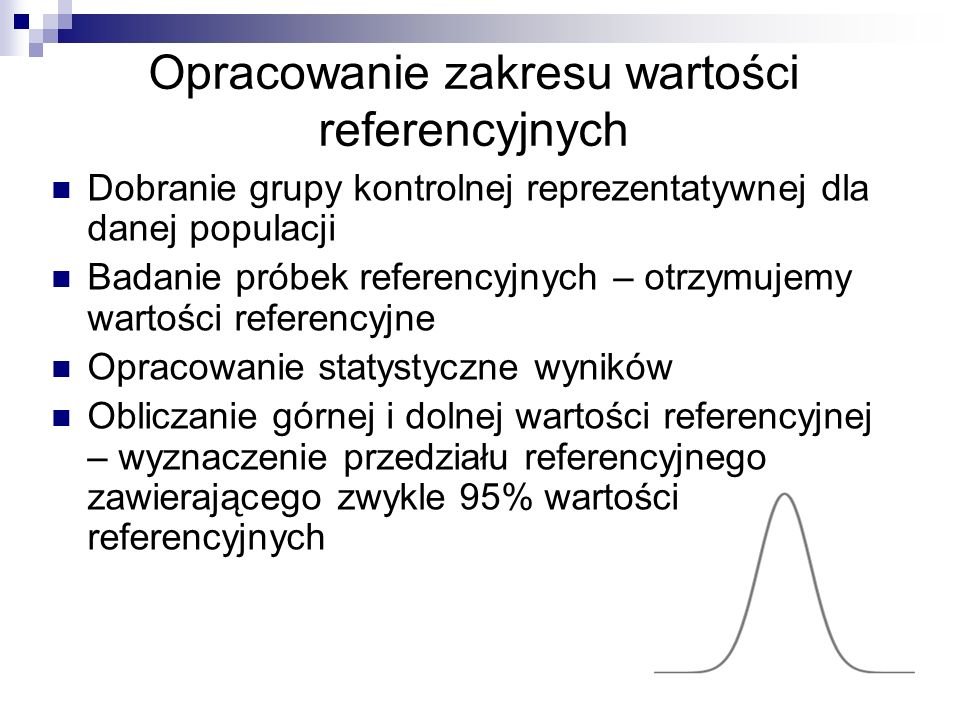

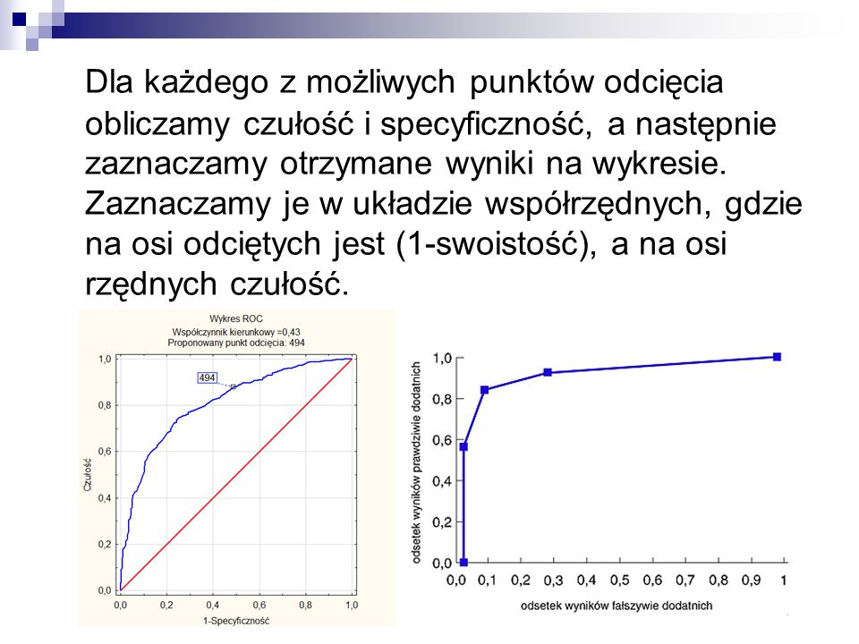

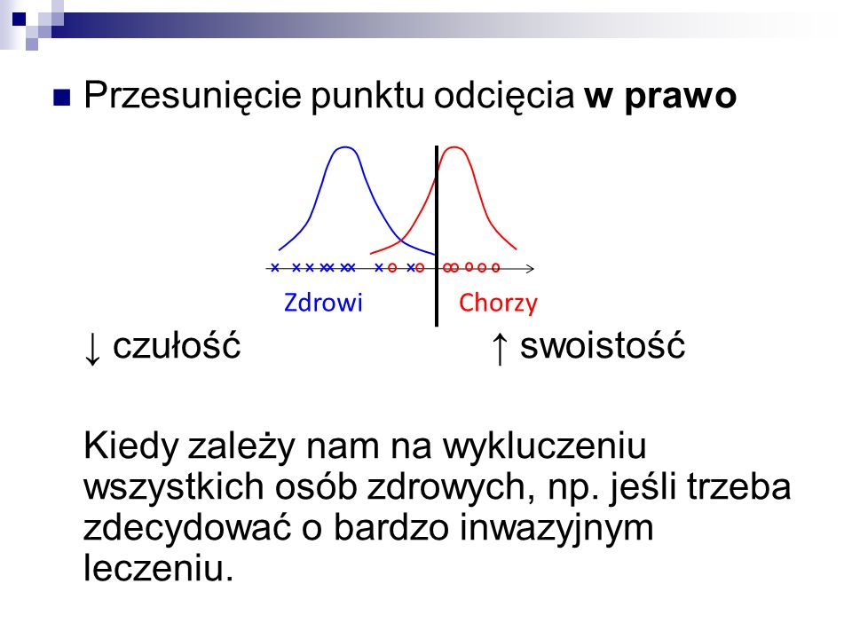

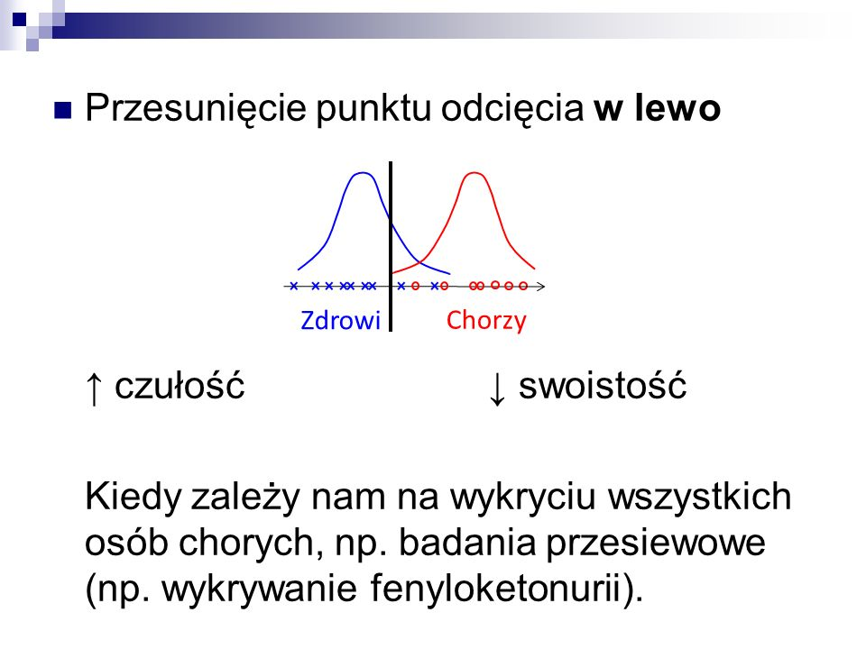

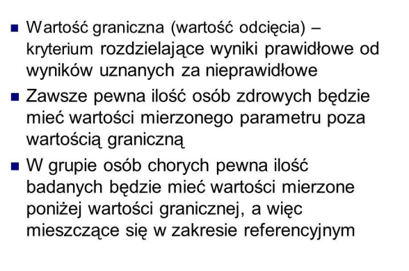

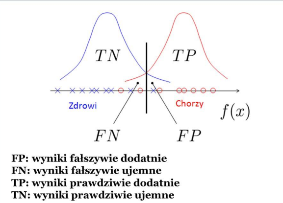

##### **Czułość diagnostyczna**

- Ilu chorych uzyskuje dodatni wynik badania?
- Wysoka czułość diagnostyczna pozwala na wykluczenie obecności choroby (mało wyników fałszywie ujemnych)

##### **Swoistość diagnostyczna**

- Ile osób wolnych od choroby uzyska ujemny wynik diagnostyczny?
- Wysoka swoistość diagnostyczna jest wskazana w przypadku podejmowania decyzji o leczeniu znacząco obciążającym chorego np. koronarografii, biopsji narządowej czy laparotomii

#### **Medycyna oparta na faktach**

Medycyna oparta na faktach,inaczej mówiąc medycyna oparta na dowodach naukowych, jest zbiorem najlepszych wiarygodnych aktualnych danych, które pozwalają precyzyjnie i dokładnie wykorzystać dostępne dowody naukowe w codziennej praktyce klinicznej.

[output not shown]

| Poziom | Opis |
| --- | --- |
| **Poziom A** | Dane pochodzące z wielu randomizowanych prób klinicznych lub metaanaliz |
| **Poziom B** | Dane pochodzące z jednej randomizowanej próby klinicznej lub dużych badań nierandomizowanych |
| **Poziom C** | Uzgodniona opinia ekspertów i/lub dane pochodzące z małych badań, badań retrospektywnych i rejestrów |

- Medycyna oparta na faktach powstała z połączenia nauki (Research) i praktyki klinicznej (Practice).
- Pozwala zastosować wiedzę uzyskaną z badań naukowych (tzw. dowód)przy podejmowaniu decyzji klinicznej, zarówno w diagnostyce chorób, jak i postępowaniu terapeutycznym w odniesieniu do konkretnego pacjenta.
- Przy podejmowaniu decyzji klinicznej należy kierować się dowodami naukowymi, które zawierają klasę zaleceń I oraz poziom wiarygodności A.

#### **Rodzaje klinicznych badań naukowych postrzega się pod względem wiarygodności gromadzenia informacji w sposób następujący:**

- metaanalizy badań z randomizacją (metanalysis)
- randomizowane kontrolowane badania kliniczne
- badania kohortowe (cohort studies)
- badania kliniczno-kontrolne (case-controlled studies)
- badania przekrojowe (cross sectional studies)
- opis przypadku (case report) lub serii przypadków (case reports).

#### **Metaanaliza:**

1. ilościowa synteza wyników wszystkich wiarygodnych badań dotyczących tego samego pytania klinicznego
2. podobnie badana populacja, interwencja, punkty końcowe lub oceniane zmienne
3. za pomocą odpowiednich metod statystycznych

#### **Przegląd systematyczny:**

1. jakościowy przegląd wszystkich badań dotyczących tego samego pytania klinicznego, zagadnienia
2. podobnie badana populacja, interwencja i punkty końcowe
3. może obejmować metaanalizę

#### **Badanie kohortowe:**

1. badanie obserwacyjne, w którym ocenia się prospektywnie wystąpienie określonego punktu końcowego w grupie osób/ chorych narażonych i nienarażonych na dany czynnik lub interwencję, u których nie stwierdzono badanego punktukońcowego na początku obserwacji
2. kohorta powinna być wyodrębniona z populacji ze względu na zachodzące jednocześnie dla całego zbioru wydarzenie (chorobę, czynnik) grupą, która jest jednorodna na podstawie statystycznych cech (np. chorzy z przewlekłą chorobą nerek)

#### **Hipoteza badawcza:**

1. tzw. domysł, przypuszczenie, które wymaga sprawdzenia, czyli weryﬁkacji poprzez odpowiednie badania stosowane w danej nauce
2. propozycja odpowiedzi na zadane pytanie, wynikające z problemu badawczego, jest propozycją twierdzenia naukowego

#### **Punkt końcowy (tzw. twardy punkt końcowy, hard end point):**

1. zdeﬁniowana w badaniu zmiana w stanie zdrowia (np. zawał serca niezakończony zgonem, udar niezakończony zgonem, niewydolność nerek, zgon), która może wystąpić u osoby uczestniczącej w badaniu, której wystąpienie albo niewystąpienie może być związane z ekspozycją na określony czynnik lub interwencję
2. na podstawie różnicy w częstości występowania punktów końcowych w badanych grupach porównuje się skuteczność i bezpieczeństwo różnych interwencji (np. leków lub zabiegów)

#### **Bezwzględne zwiększenie ryzyka (ARI, absolute risk increase):**

1. bezwzględna różnica pomiędzy ryzykiem w grupie eksperymentalnej i w grupie kontrolnej
2. określa o ile zwiększyło się ryzyko wystąpienia niekorzystnego punktu końcowego w wyniku ekspozycji na dany czynnik lub interwencję

#### **Bezwzględne zmniejszenie ryzyka (ARR, absolute risk reduction):**

1. bezwzględna różnica pomiędzy ryzykiem w grupie kontrolnej i ryzykiem w grupie eksperymentalnej.
2. określa bezwzględną wielkość usuniętego ryzyka
3. stosuje się w badaniach, w których ekspozycja na dany czynnik lub interwencję zmniejsza prawdopodobieństwo wystąpienia niekorzystnego punktu końcowego

#### **Ryzyko względne (RR, relative risk):**

1. w badaniach skuteczności i bezpieczeństwa interwencji (np. leków, zabiegów) jest to iloraz prawdopodobieństwa wystąpieniaokreślonego punktu końcowego w grupie eksperymentalnej, wktórej stosuje się ocenianą interwencję i tego prawdopodobieństwa w grupie kontrolnej
2. jest to część ryzyka podstawowego, jaka pozostała po interwencji
3. w badaniach związków przyczynowo-skutkowych (np. dotyczących rokowania) jest to iloraz prawdopodobieństwa wystąpienia określonego punktu końcowego w grupie, w której występuje dany czynnik i tego prawdopodobieństwa w grupie kontrolnej

#### **Hazard względny (HR, hazard ratio):**

1. pojęcie podobnie jak RR.
2. określa względne prawdopodobieństwo zajścia jakiegoś zdarzenia w badanych grupach w określonym czasie przy założeniu, że zdarzenie to do tej pory nie wystąpiło (określa część ryzyka podstawowego pozostałą po interwencji)

#### **Iloraz szans (OR, odds ratio):**

1. iloraz szansy wystąpienia określonego stanu klinicznego w grupie eksponowanej na dany czynnik lub interwencję i szansy wystąpienia tego stanu w grupie nieeksponowanej (kontrolnej).
2. szansa to stosunek prawdopodobieństwa wystąpienia określonego stanu klinicznego do prawdopodobieństwa jego niewystąpienia w danej grupie

#### **Liczba konieczna do leczenia (NNT, number needed to treat):**

1. liczba pacjentów, których trzeba poddać danej interwencji przez określony czas, aby zapobiec jednemu niekorzystnemu punktowi końcowemu
2. NNT wylicza się jako odwrotność ARR (1/ARR)

#### **NNH (NNH, number needed to harm):**

1. liczba pacjentów, których interwencja/leczenie przez określony czas prowadzi do wystąpienia jednego niekorzystnego punktu końcowego
2. NNH wylicza się jako odwrotność ARI (1/ARI)

#### **Przedział ufności (Cl, conﬁdence interval):**

1. określa stopień precyzji danego oszacowania
2. zwykle podaje się 95% Cl, czyli przedział, w którym z 95% pewnością znajduje się prawdziwa wartość danego parametru w badanej populacji
3. im węższy przedział ufności, tym bardziej precyzyjne oszacowanie
4. jeśli w przedziale ufności zawarte jest 0 dla różnicy ryzyka, a 1 dla ryzyka względnego albo ilorazu szans, jest to równoznaczne z brakiem istotności statystycznej danego wyniku (p>0,05)

#### **Istotność statystyczna:**

1. oznacza maksymalne dopuszczalne prawdopodobieństwo popełnienia błędu I rodzaju
2. najczęściej jest to wartość wyliczonego z testu statystycznego poziomu istotności p (p-value), który świadczy o wynikach istotnie statystycznych
3. za taką wartość progową przyjmuję się p=0.05. Dla przykładu p=0.027 odpowiada 2,7% prawdopodobieństwu popełnienia błędu

#### **Próba otwarta** - badanie, w którym pacjenci i badacze znają przynależność do grupy eksperymentalnej albo kontrolnej

#### **Próba podwójnie ślepa:**

- badanie, w którym ani sam pacjent, ani badacze nie wiedzą, jakiej interwencji (eksperymentalnej czy kontrolnej) jest on poddany
- to określenie wymaga dokładniejszego sprecyzowania w metodyce badania, ponieważ o przynależności do grupy eksperymentalnej albo kontrolnej mogą nie wiedzieć również osoby kwaliﬁkujące chorych do badania, zespół leczący oraz osoby analizujące wyniki

#### **Próba pojedynczo ślepa** - badanie, w którym jedynie pacjenci nie wiedzą, jakiej interwencji (eksperymentalnej czy kontrolnej) są poddani

#### **Model badania naukowego**

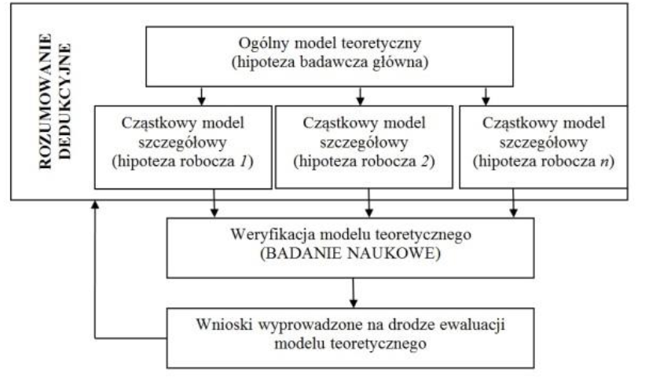

- model nomologiczno-dedukcyjny

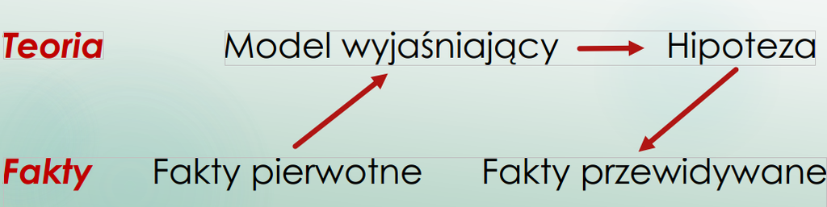

- model hipotetyczno-dedukcyjny

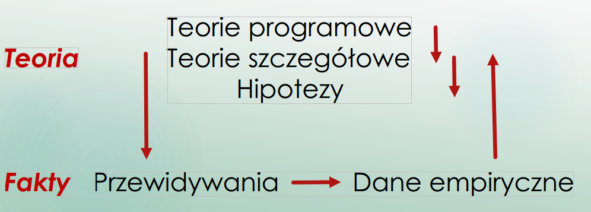

#### **Etapy badania naukowego**

1. Sformułowanie problemu
2. Postawienie hipotez teoretycznych 3. Operacjonalizacja
3. Weryfikacja hipotez
4. Generalizacja wyników

#### **Klasyfikacja zmiennych**

1. Zmienna jest to cecha przedmiotu, która może przybierać dwie lub więcej wartości
2. Zmienna wyjaśniana nosi nazwę zmiennej zależnej – zapisujemy symbolem Y (np. powodzenie w nauce szkolnej)
3. Zmienne, które wpływają na zmienną Y nazywane są niezależnymi - oznaczamy je symbolem X (np. inteligencja, motywacja, płeć, etc.)

#### **Zmienne Zakłócające**

1. Nie związane z badaniem
2. Związane z badaniem
- Uniwersalne
  - Kontrolowane
  - Niekontrolowane
- Okazjonalne
  - Kontrolowane
  - Niekontrolowane

#### **Badanie korelacyjne**

##### **Badanie eksperymentalne**

- Badacz ma pełną kontrolę nad zmienną zależną
- Kontroluje pozostałe zmienne niezależne uboczne i zakłócające
- Dokonuje pomiaru zmiennej zależnej

#### **Randomizacja**

- **Randomizacja I stopnia** - Wybór grupy reprezentatywnej
- **Randomizacja II stopnia** - Dobór losowy

#### **Trafność wewnętrzna – czynniki zakłócające**

1. Historia – zdarzenia losowe nie kontrolowane przez badacza, które wpłynęły na przebieg eksperymentu
2. Dojrzewanie – spontaniczny rozwój organizmu w trakcie badań
3. Testowanie – uczenie się przez badanych procedury zmiennej
4. Selekcja – dobór niejednorodnych grup badanych

#### **Trafność zewnętrzna – czynniki zakłócające**

1. Niewłaściwa randomizacja I stopnia (mało reprezentatywna grupa)
2. Niewłaściwy zakres zmiennej niezależnej
3. Interakcje z czynnikiem eksperymentalnym
- Schemat bez pretestu (baseline)
- Schemat bez grupy kontrolnej
- Schemat mieszany (1 + 2)

#### **Analiza post-hoc**

1. Zadaniem badacza nie jest wywołanie zjawisk, lecz wyjaśnienie przyczyn zjawisk, które już zaszły
2. Istnieją zjawiska, które z przyczyn metodologicznych lub etycznych nie mogą być badane na drodze eksperymentalnej (np. zaburzenia psychiczne, przestępczość, etc.)
3. Badacz wyszukuje grupy różniące się pod względem badanej zmiennej zależnej, a następnie stara się zbadać możliwie dokładnieróżnice pomiędzy tymi grupami

### Teoria i planowanie

##### Każdy człowiek jest odbiorcą pewnej wiedzy powstałej w mniej lubbardziej „naukowy” sposób:

• „jak dowodzą badania naukowe” • „jak wynika z testów klinicznych”

- Obowiązek rzetelności naukowej spoczywa nie tylko na osobie prowadzącej badanie, ale również na odbiorcy wyników tych badań
- Każdy dziedzina nauki ma swoje metody badawcze
- Nauki szczegółowe badają pewien wycinek rzeczywistości
  - Redukcja tematyczna (określony przedmiot, dziedzina badań)
  - Abstrakcja metodyczna (specyficzna metoda badań)
- Redukcja tematyczna i abstrakcja metodyczna mogą prowadzić do uzyskiwania sprzecznych wyników

##### **Nauki indukcyjne i dedukcyjne**

- Nauki dedukcyjne konstruują swój system wiedzy wychodząc z określonych założeń, które pozwalają na wyciąganieszczegółowych konsekwencji (np. matematyka, filozofia, prawo)
- Nauki indukcyjne starają się gromadzić obserwacje jednostkowych faktów i na ich podstawie formułować prawa ogólne
- Nauki empiryczne są naukami indukcyjnymi

##### **Nauki empiryczne i nieempiryczne**

- Nauki formalne (nieempiryczne) zajmują się opisem cech stałych i ogólnych
- Nauki empiryczne zajmują się zmiennością zjawisk („tym co ruchome”)

##### **Podział nauk wg. Arystotelesa**

1. **Teoretyczne** - których celem jest formułowanie wiedzy dla niej samej (metafizyka, fizyka i matematyka)
2. **Praktyczne** - których celem jest formułowanie wiedzy dla osiągnięcia doskonałości moralnej (etyka, polityka)
3. **Pojetyczne** (wytwórcze, od gr. poiesis) - których celem jest formułowanie wiedzy, za pomocą której można wytwarzaćokreślone przedmioty *Nauki teoretyczne są najbardziej wartościowe, ze względu na fakt, że opisują wiedzę dla samej wiedzy. Np. metafizyka, która dąży do zaspokojenia tylko i wyłącznie ludzkiej potrzeby czystego poznania*

##### **Sprawdzalność**

1. Zasada: wynik eksperymentu czy obserwacji powinien dać się powtórzyć w podobnych warunkach
2. Problemy:
- **Czas:** unikalne obserwacje astronomiczne (raz na kilka lat)
- **Unikalność:** ekstremalne warunki (np. badania u wspinaczy w górach wysokich, kosmonautów, etc.)

##### **Obiektywizm**

1. Badacz powinien prowadzić badania w sposób obiektywny, nie starając się na siłę udowodnić swoich hipotez
2. Wynik może być cenny dla nauki niezależnie od tego, czy potwierdza teorię badacza, czy też nie

##### **Prawdziwość pojęć teoretycznych**

- Pozwala uporządkować teorię
- Trafnie opisuje rzeczywistość

#### **Prawdziwość teorii naukowych**

1. Teoria nie może być sprzeczna z obserwowanymi faktami
2. Teoria stanowiąca zestaw zdań zawsze prawdziwych zwykle jest mało użyteczna
3. „Gdy w świętego Hieronima jest deszcz albo go ni ma, to na świętego Prota będzie słonko albo słota”
4. W teorię musi być wbudowana możliwość jej konfrontacji z rzeczywistością
- Zadaniem wiedzy naukowej jest **opis, wyjaśnianie i opisywanie** rzeczywistości

### TO JUŻ WSZYSTKO DZIĘKI ZA UWAGĘ ŚWIRKI